# Lab 6

```python
import pandas as pd
from sklearn.pipeline import Pipeline
from sklearn.linear_model import LinearRegression
from sklearn.model_selection import cross_val_score
from sklearn.model_selection import GridSearchCV
from sklearn.linear_model import ElasticNet, Ridge, Lasso
```

```python
url = 'https://www.dropbox.com/s/boshaqfgdjiaxh4/Hitters.csv?dl=1'
df = pd.read_csv(url)
```

Cleaning data

```python
# Remove rows with missing values
df = df.dropna()

# Create dummy variables for categorical columns
df = pd.get_dummies(df, drop_first=True)
```

Part A: Pipline for all variables, ordinary linear regression

```python
X = df.drop('Salary', axis=1)
y = df['Salary']


pipeline = Pipeline([
    ('regressor', LinearRegression())
])

pipeline.fit(X, y)
```

```
Pipeline(steps=[('regressor', LinearRegression())])
```

Get coefficients

```python
coefficients = pd.DataFrame({
    'Feature': X.columns,
    'Coefficient': pipeline.named_steps['regressor'].coef_
})


coefficients['Abs_Coef'] = coefficients['Coefficient'].abs()
coefficients = coefficients.sort_values('Abs_Coef', ascending=False)

print("Top 10 Most Important Coefficients:")
print(coefficients[['Feature', 'Coefficient']].head(10))
```

```
Top 10 Most Important Coefficients:
        Feature  Coefficient
17   Division_W  -116.849246
16     League_N    62.599423
18  NewLeague_N   -24.762325
1          Hits     7.500768
5         Walks     6.231286
2         HmRun     4.330883
6         Years    -3.489054
15       Errors    -3.360760
3          Runs    -2.376210
0         AtBat    -1.979873
```

Interpretation: league N plyers mke much more than divsion w, newleagueN players make less than those already there, hits is the best performance metric for a players salary.

Cross validation

```python
mse_scores = cross_val_score(pipeline, X, y, cv=5, scoring='neg_mean_squared_error')
mse = -mse_scores.mean()

print(f"Estimated MSE: {mse:.2f}")
```

```
Estimated MSE: 121136.31
```

Part B: Rdige regession

```python
pipeline = Pipeline([
    ('regressor', Ridge())
])

pipeline.fit(X, y)
```

```
Pipeline(steps=[('regressor', Ridge())])
```

cross valid to tune lambda

```python
param_grid = {'regressor__alpha': [0.01, 0.1, 1, 10, 100, 1000]}
grid_search = GridSearchCV(pipeline, param_grid, cv=5, scoring='neg_mean_squared_error')
grid_search.fit(X, y)
```

```
GridSearchCV(cv=5, estimator=Pipeline(steps=[('regressor', Ridge())]),
             param_grid={'regressor__alpha': [0.01, 0.1, 1, 10, 100, 1000]},
             scoring='neg_mean_squared_error')
```

Fitting to orginal dta

```python
coefficients = pd.DataFrame({
    'Feature': X.columns,
    'Coefficient': grid_search.best_estimator_.named_steps['regressor'].coef_
})

coefficients['Abs_Coef'] = coefficients['Coefficient'].abs()
coefficients = coefficients.sort_values('Abs_Coef', ascending=False)

print("\nTop 10 Most Important Coefficients:")
print(coefficients[['Feature', 'Coefficient']].head(10))
```

```
Top 10 Most Important Coefficients:
        Feature  Coefficient
17   Division_W   -44.591145
16     League_N    14.191182
1          Hits     7.653206
18  NewLeague_N     7.394665
5         Walks     6.102053
15       Errors    -2.997137
2         HmRun     2.892573
6         Years    -2.335595
0         AtBat    -2.114978
3          Runs    -2.091896
```

Interpreation: being in division W has much lowers salary then those in league N, the amount of hits a plyer gets is the best performance metric for their salary

MSE for 1989 salary

```python
print(f"Best alpha: {grid_search.best_params_['regressor__alpha']}")
print(f"Best MSE: {-grid_search.best_score_:.2f}")
```

```
Best alpha: 100
Best MSE: 120041.91
```

Part c: Lasso regression

```python
pipeline = Pipeline([
    ('regressor', Lasso())
])

pipeline.fit(X, y)
```

```
Pipeline(steps=[('regressor', Lasso())])
```

tuning lambda

```python
param_grid = {'regressor__alpha': [0.01, 0.1, 1, 10, 100, 1000]}
grid_search = GridSearchCV(pipeline, param_grid, cv=5, scoring='neg_mean_squared_error')
grid_search.fit(X, y)
```

[output not shown]

[output cut: 30 more lines]

```
GridSearchCV(cv=5, estimator=Pipeline(steps=[('regressor', Lasso())]),
             param_grid={'regressor__alpha': [0.01, 0.1, 1, 10, 100, 1000]},
             scoring='neg_mean_squared_error')
```

Fitting and getting coeffiencts

```python
coefficients = pd.DataFrame({
    'Feature': X.columns,
    'Coefficient': grid_search.best_estimator_.named_steps['regressor'].coef_
})


coefficients['Abs_Coef'] = coefficients['Coefficient'].abs()
coefficients = coefficients.sort_values('Abs_Coef', ascending=False)

print("\nTop 10 Most Important Coefficients:")
print(coefficients[['Feature', 'Coefficient']].head(10))
```

```
Top 10 Most Important Coefficients:
    Feature  Coefficient
1      Hits     5.874229
5     Walks     4.766074
0     AtBat    -1.731027
10    CRuns     1.284948
11     CRBI     0.745584
12   CWalks    -0.597987
8     CHits     0.337933
13  PutOuts     0.290386
14  Assists     0.265466
7    CAtBat    -0.226869
```

League is no longer important, but performance metrics such as hits and walks are now more important.

MSE for 1989 salary

```python
print(f"Expected MSE: {-grid_search.best_score_:.2f}")
```

```
Expected MSE: 118950.41
```

Part D Elastic Net

```python
pipeline = Pipeline([
    ('regressor', ElasticNet())
])

pipeline.fit(X, y)
```

```
Pipeline(steps=[('regressor', ElasticNet())])
```

Tuning lambda and alpha

```python
param_grid = {
    'regressor__alpha': [0.01, 0.1, 1, 10, 100],
    'regressor__l1_ratio': [0.1, 0.3, 0.5, 0.7, 0.9]
}
grid_search = GridSearchCV(pipeline, param_grid, cv=5, scoring='neg_mean_squared_error')
grid_search.fit(X, y)
```

[output not shown]

[output cut: 204 more lines]

```
GridSearchCV(cv=5, estimator=Pipeline(steps=[('regressor', ElasticNet())]),
             param_grid={'regressor__alpha': [0.01, 0.1, 1, 10, 100],
                         'regressor__l1_ratio': [0.1, 0.3, 0.5, 0.7, 0.9]},
             scoring='neg_mean_squared_error')
```

Fit and get coeffiecnts

```python
coefficients = pd.DataFrame({
    'Feature': X.columns,
    'Coefficient': grid_search.best_estimator_.named_steps['regressor'].coef_
})

coefficients = coefficients[coefficients['Coefficient'] != 0]
coefficients['Abs_Coef'] = coefficients['Coefficient'].abs()
coefficients = coefficients.sort_values('Abs_Coef', ascending=False)

print(f"\nNumber of selected features: {len(coefficients)}")
print("\nMost Important Coefficients:")
print(coefficients[['Feature', 'Coefficient']].head(10))
```

```
Number of selected features: 10

Most Important Coefficients:
    Feature  Coefficient
1      Hits     5.439653
5     Walks     4.503303
0     AtBat    -1.576603
10    CRuns     1.260893
11     CRBI     0.744795
12   CWalks    -0.562349
8     CHits     0.390390
13  PutOuts     0.289933
14  Assists     0.260513
7    CAtBat    -0.241483
```

Hits and walks are the most importnt coeffiencts for increasing salary.

1989 salary mse

```python
print(f"Expected MSE: {-grid_search.best_score_:.2f}")
```

```
Expected MSE: 118994.02
```

Part 2. Variable Selection

```python
df_encoded = pd.get_dummies(df, drop_first=True)
X = df_encoded.drop('Salary', axis=1)
y = df_encoded['Salary']
```

```python
import numpy as np
models = {
    'OLR': LinearRegression(),
    'Ridge': GridSearchCV(Ridge(), {'alpha': [0.01, 0.1, 1, 10, 100, 1000]}, cv=5, scoring='neg_mean_squared_error'),
    'Lasso': GridSearchCV(Lasso(max_iter=10000), {'alpha': [0.01, 0.1, 1, 10, 100, 1000]}, cv=5, scoring='neg_mean_squared_error'),
    'ElasticNet': GridSearchCV(ElasticNet(max_iter=10000), {'alpha': [0.01, 0.1, 1, 10, 100], 'l1_ratio': [0.1, 0.3, 0.5, 0.7, 0.9]}, cv=5, scoring='neg_mean_squared_error')
}

all_coefs = []
for name, model in models.items():
    model.fit(X, y)
    if hasattr(model, 'best_estimator_'):
        coefs = model.best_estimator_.coef_
    else:
        coefs = model.coef_
    all_coefs.append(pd.Series(np.abs(coefs), index=X.columns, name=name))

# Combine coefficients from all models
coef_df = pd.concat(all_coefs, axis=1)
coef_df['Average'] = coef_df.mean(axis=1)
coef_df = coef_df.sort_values('Average', ascending=False)

print("Top coefficients across all models:")
print(coef_df.head(10))
print()
```

```
Top coefficients across all models:
                    OLR      Ridge     Lasso  ElasticNet    Average
Division_W   116.849246  44.591145  0.000000    0.000000  40.360098
League_N      62.599423  14.191182  0.000000    0.000000  19.197651
NewLeague_N   24.762325   7.394665  0.000000    0.000000   8.039247
Hits           7.500768   7.653206  5.877149    5.440936   6.618015
Walks          6.231286   6.102053  4.767354    4.503877   5.401143
AtBat          1.979873   2.114978  1.731986    1.577023   1.850965
HmRun          4.330883   2.892573  0.000000    0.000000   1.805864
Errors         3.360760   2.997137  0.000000    0.000000   1.589474
Years          3.489054   2.335595  0.000000    0.000000   1.456162
CRuns          1.454305   1.559935  1.285447    1.261126   1.390203
```

Best Numeric varialbe is Hits. The tp5 numerical varibles are Hits, walks, Atbat, Hmrun, and Errors. The most important categorical variable is Division_W.

New Model only using the best variables

```python
best_numeric = 'Hits'
top_5_numeric = ['Hits', 'Walks', 'AtBat', 'HmRun', 'Errors']
best_categorical = 'Division_W'

# Create feature sets
X1 = df[[best_numeric]]

X2 = df[top_5_numeric]

X3 = pd.get_dummies(df[top_5_numeric + [best_categorical]], drop_first=True)
for col in top_5_numeric:
    for cat in [c for c in X3.columns if best_categorical in c]:
        X3[f'{col}*{cat}'] = X3[col] * X3[cat]

feature_sets = [
    ('Best numeric only', X1),
    ('Top 5 numeric', X2),
    ('Top 5 + categorical interactions', X3)
]
```

```python
models = [
    ('OLR', LinearRegression(), {}),
    ('Ridge', Ridge(), {'alpha': [0.01, 0.1, 1, 10, 100, 1000]}),
    ('Lasso', Lasso(max_iter=10000), {'alpha': [0.01, 0.1, 1, 10, 100, 1000]}),
    ('ElasticNet', ElasticNet(max_iter=10000), {
        'alpha': [0.01, 0.1, 1, 10, 100],
        'l1_ratio': [0.1, 0.3, 0.5, 0.7, 0.9]
    })
]
```

```python
results = []
for fname, X in feature_sets:
    print(f"\n{fname}:")
    for mname, model, params in models:
        if params:
            grid = GridSearchCV(model, params, cv=5, scoring='neg_mean_squared_error')
            grid.fit(X, y)
            mse = -grid.best_score_
            best_params = grid.best_params_
        else:
            mse = -cross_val_score(model, X, y, cv=5, scoring='neg_mean_squared_error').mean()
            best_params = None

        results.append((mname, fname, mse, best_params))
        print(f"  {mname:11} | MSE: {mse:8.2f} | {best_params if best_params else ''}")
```

```
Best numeric only:
  OLR         | MSE: 173088.97 |
  Ridge       | MSE: 173064.83 | {'alpha': 1000}
  Lasso       | MSE: 173058.37 | {'alpha': 100}
  ElasticNet  | MSE: 172721.80 | {'alpha': 100, 'l1_ratio': 0.1}

Top 5 numeric:
  OLR         | MSE: 157152.99 |
  Ridge       | MSE: 156646.19 | {'alpha': 1000}
  Lasso       | MSE: 157076.46 | {'alpha': 10}
  ElasticNet  | MSE: 156352.33 | {'alpha': 10, 'l1_ratio': 0.1}

Top 5 + categorical interactions:
  OLR         | MSE: 183031.32 |
  Ridge       | MSE: 179394.23 | {'alpha': 1}
```

[output not shown]

[output cut: 69 more lines]

[output not shown]

```
  Lasso       | MSE: 176072.67 | {'alpha': 100}
```

[output not shown]

[output cut: 220 more lines]

```
  ElasticNet  | MSE: 176549.71 | {'alpha': 100, 'l1_ratio': 0.9}
```

Part 3. Discussion A. Ridge In the ordinary regression model the coeffiencts were large, such as divsion_W being -116 vs Ridge ws -44. While the postive and negative effects of a variable on salary were all equal. The top 3 vars for the ordariny model were divsion_w , league_n and newleague_n. the top 3 variables for rigde was divsion_w, league_n and hits.

Part 4: Final Model

```python
import pandas as pd
import numpy as np
from plotnine import *
from sklearn.linear_model import ElasticNet
from sklearn.model_selection import GridSearchCV, cross_val_predict
```

```python
y_pred = cross_val_predict(grid_search.best_estimator_.named_steps['regressor'], X, y, cv=5)

mse = np.mean((y - y_pred)**2)
r2 = 1 - (np.sum((y - y_pred)**2) / np.sum((y - y.mean())**2))

print(f"MSE: {mse:.2f}")
print(f"R2: {r2:.3f}")
```

```
MSE: 171557.72
R2: 0.154
```

```python
coef_array = grid_search.best_estimator_.named_steps['regressor'].coef_
print(f"Number of features: {len(X.columns)}")
print(f"Number of coefficients: {len(coef_array)}")
```

[output not shown]

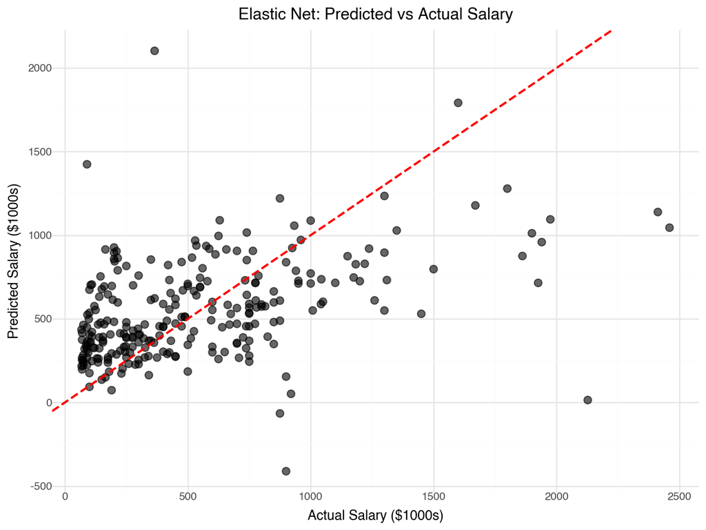

```python
coefs = pd.DataFrame({
    'Feature': X.columns[:len(coef_array)],
    'Coefficient': coef_array
})
coefs = coefs[coefs['Coefficient'] != 0].sort_values('Coefficient', key=abs, ascending=False).head(10)


pred_df = pd.DataFrame({'Actual': y.values, 'Predicted': y_pred})

plot = (ggplot(pred_df, aes(x='Actual', y='Predicted')) +
        geom_point(alpha=0.6, color='black', size=3) +
        geom_abline(slope=1, intercept=0, color='red', linetype='dashed', size=1) +
        labs(title='Elastic Net: Predicted vs Actual Salary',
             x='Actual Salary ($1000s)',
             y='Predicted Salary ($1000s)') +
        theme_minimal() +
        theme(figure_size=(8, 6)))

plot
```

I plotted my elastic moedel. When comparing the predicted vlues to the actual values we can see there is bit of discrepency. This becasue the actual salary values are not consitant or have predictors very correlated to eachother. The plot shows of the ctual values make sort of a squre, so it is near impossible to get a linear regression line that is able to fit it with high accuracy.